# Relatório Prova Prática 1 - Séries Temporais

### 1) Análise da concentração de partículas inaláveis finas (MP$_{2.5}$) da cidade de London, província de Ontário, Canadá, no ano de 2013

#### Contextualização do problema:

O arquivo Matter2013-London.csv, obtido em www.airqualityontario.com, contém informações sobre as concentrações de partículas inaláveis finas (MP$_{2,5}$, em $\mu g/m^{3}$ ), registradas no ano de 2013 em London, cidade situada na província canadense de Ontário. Os valores são registrados a cada hora. Para determinado dia D, as variáveis $\textit{H}_{1}$ a $\textit{H}_{24}$ representam as medições feitas na primeira até a $24^{ª}$ hora do dia, respectivamente.

O objetivo desta análise é fazer uma análise exploratória desta série temporal dada por:

$$Y_{t} = min\{H_{j,t}\}$$

#### item i)

Dados brutos antes do tratamento:

```r
# ----- leitura e carregamento
library(tibbletime)
library(dplyr)
library(ggplot2)
library(readr)
library(lubridate)
library(reshape2)

matter.loc <- "/home/allan/Documents/1S2018/A_SERIES_TEMPORAIS/aulas/dados/Matter2013-London.csv"

matter <- read_csv(matter.loc)
head(matter)
```

| Station ID | Pollutant | Date | H01 | H02 | H03 | H04 | H05 | H06 | H07 | H08 | H09 | H10 | H11 | H12 | H13 | H14 | H15 | H16 | H17 | H18 | H19 | H20 | H21 | H22 | H23 | H24 | X28 |
| --- | --- | --- | --- | --- | --- | --- | --- | --- | --- | --- | --- | --- | --- | --- | --- | --- | --- | --- | --- | --- | --- | --- | --- | --- | --- | --- | --- |
| 15026 | Fine Particulate Matter | 2013-01-01 | 9 | 7 | 5 | 4 | 3 | 4 | 4 | 4 | 4 | 3 | 3 | 4 | 3 | 4 | 4 | 4 | 4 | 4 | 4 | 4 | 4 | 8 | 10 | 7 | NA |
| 15026 | Fine Particulate Matter | 2013-01-02 | 5 | 6 | 7 | 7 | 6 | 5 | 8 | 8 | 7 | 7 | 6 | 7 | 10 | 9 | 8 | 7 | 8 | 12 | 24 | 20 | 14 | 11 | 13 | 24 | NA |
| 15026 | Fine Particulate Matter | 2013-01-03 | 22 | 14 | 12 | 9 | 7 | 7 | 12 | 15 | 13 | 9 | 9 | 14 | 21 | 21 | 23 | 27 | 35 | 37 | 41 | 43 | 43 | 42 | 31 | 23 | NA |
| 15026 | Fine Particulate Matter | 2013-01-04 | 17 | 16 | 14 | 13 | 15 | 18 | 16 | 15 | 12 | 11 | 11 | 11 | 11 | 11 | 11 | 11 | 11 | 11 | 11 | 11 | 12 | 14 | 16 | 18 | NA |
| 15026 | Fine Particulate Matter | 2013-01-05 | 20 | 22 | 25 | 26 | 27 | 27 | 27 | 28 | 29 | 29 | 30 | 28 | 24 | 22 | 20 | 20 | 19 | 22 | 22 | 20 | 15 | 13 | 14 | 18 | NA |
| 15026 | Fine Particulate Matter | 2013-01-06 | 24 | 26 | 21 | 18 | 17 | 17 | 16 | 15 | 15 | 18 | 21 | 19 | 19 | 20 | 20 | 20 | 19 | 18 | 20 | 18 | 20 | 10 | 6 | 5 | NA |

Dados após preparação:

```r
# ----- data preparation

# passando para formato long;
# eliminando as duas primeiras colunas;
# eliminando os NA's e as entradas com 9999 e -999;
# agrupando por dia e calculando o minimo
matter2 <- matter %>%
  dplyr::select(-(1:2)) %>% # eliminando duas primeiras colunas
  melt(id.vars = "Date") %>% # to long
  magrittr::set_colnames(c("Date", "hora", "MP")) %>%
  dplyr::arrange(Date, hora) %>% # ordenar por dia/hora
  mutate(MP = replace(MP, MP == 9999 | MP == -999, NA)) %>% # sol: https://stackoverflow.com/questions/35610437/using-dplyr-to-conditionally-replace-values-in-a-column
  na.omit() %>%
  group_by(Date) %>%
  summarise(MP = as.numeric(min(MP, na.rm=TRUE))) # a serie eh baseada no minimo do dia
  # nao precisamos das horas


# passando para tibble e tibbletime:
matter3 <- matter2 %>%
  #tibble::as_tibble() %>%
  #na.omit() %>% # eliminando os NA's
  mutate(Date = lubridate::ymd(Date)) %>% # usando ymd do lubridate
  as_tbl_time(index = Date)



head(matter3)
```

[output not shown]

Gráficos da série temporal $Y_{t}$:

```r
# ----- plots serie:

# --- serie:
# ggplot:
# matter3 %>%
# ggplot() +
#   geom_line(aes(x = Date, y = MP), colour="orange") +
#   theme_minimal()+
#   labs(title="Série diária de MP")

# dygraphs
library(dygraphs)
library(xts)
matter3_ts <- xts(matter3 %>% dplyr::select(MP), order.by=matter3$Date)
# dygraph(matter3_ts, elementId='matter3') %>% dyRangeSelector()# %>% dyUnzoom()
dygraph(matter3_ts, elementId='matter3', main="Série diária de MP" ) %>% dyRangeSelector() %>% dyUnzoom() %>%
  dySeries("MP", color = "orange")
```

[interactive chart not shown]

```r
# rCharts:
# library(rCharts)
# library(rjson)
# dPlot(MP ~ Date, data = matter3, type="line")
```

Plots da ACF e PACF para analisar estacionariedade:

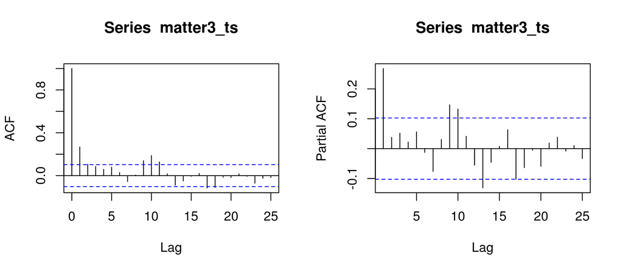

```r
# ----- plots:
par(mfrow=c(1,2))
acf(matter3_ts)
pacf(matter3_ts)
```

#### item ii)

Com base no gráfico da Função de Autocorrelação (FAC ou ACF em inglês), é possível inferir que a série **é estacionária**. Há um decaimento rápido da autocorrelação nos primeiros *lags* e, mesmo com uma certa variabilidade neste padrão, a correlação parece tender rapidamente a zero conforme $h$ aumenta. Este comportamento indica a presença de estacionariedade na série. Se houvesse um decaimento lento da FAC, isto poderia indicar o efeito de uma memória de mais longo prazo nos dados. Consequentemente, teríamos a dependência persistente (entre os valores de $Y_{t}$) ao longo do tempo e a não-estacionariedade da série, o que não é o caso.

Haveria, ainda, a possibilidade de empregarmos testes estatísticos para a existência de estacionariedade na série. Uma das possibilidades seria o teste de *Dick-Fuller* (mais especificamente *Augmented Dick-Fuller Test (ADF)*), o qual realizamos abaixo:

```r
# Augmented Dick-Fuller Test for Stationarity
tseries::adf.test(matter3_ts, alternative="stationary")
```

```
##
##  Augmented Dickey-Fuller Test
##
## data:  matter3_ts
## Dickey-Fuller = -6.3473, Lag order = 7, p-value = 0.01
## alternative hypothesis: stationary
```

Portanto, com um p-valor abaixo de $1\%$, o resultado nos permite afirmar que há evidências para se aceitar a hipótese de que a série é estacionária, considerando um nivel $\alpha$ de $5\%$ para o teste.

#### item iii)

$$Y_{t} = \mu_{0} + \rho Y_{t-1} + \epsilon_{t}$$